# Investigate Titanic Dataset

Author: Xiao Liu  
LastModify: 09/16/2017

```python
import numpy as np
import pandas as pd
import matplotlib.pyplot as plt
import seaborn as sns

titanic_df = pd.read_csv('titanic-data.csv')
```

## 1. Background Story of Titanic

RMS Titanic was a British passenger liner that sank in the North Atlantic Ocean in the early morning hours of 15 April 1912, after it collided with an iceberg during its maiden voyage from Southampton to New York City. There were an estimated 2,224 passengers and crew aboard the ship, and more than 1,500 died, making it one of the deadliest commercial peacetime maritime disasters in modern history. The RMS Titanic was the largest ship afloat at the time it entered service and was the second of three Olympic-class ocean liners operated by the White Star Line. The Titanic was built by the Harland and Wolff shipyard in Belfast. Thomas Andrews, her architect, died in the disaster. ---- from Wiki: https://en.wikipedia.org/wiki/RMS_Titanic

This data comes from part of Titanic passenger data. It includes all informations about passenger. Through analyzing of this sample data, we want to find out **What factors made people more likely to survive**.

## 2. Dataset at a Glance

### 2.1 Dataset Overview

**Dataset:** `titanic-data.csv`

**Number of rows:** 891

**Number of columns:** 12

**Data dictionary:**

| Variable | Definition | Key |
| --- | --- | --- |
| survival | Survival | 0 = No, 1 = Yes |
| pclass | Ticket class | 1 = 1st, 2 = 2nd, 3 = 3rd |
| sex | Sex |  |
| Age | Age in years |  |
| sibsp | # of siblings / spouses aboard the Titanic |  |
| parch | # of parents / children aboard the Titanic |  |
| ticket | Ticket number |  |
| fare | Passenger fare |  |
| cabin | Cabin number |  |
| embarked | Port of Embarkation | C = Cherbourg, Q = Queenstown, S = Southampton |

```python
titanic_df.head(10)
```

|  | PassengerId | Survived | Pclass | Name | Sex | Age | SibSp | Parch | Ticket | Fare | Cabin | Embarked |
| --- | --- | --- | --- | --- | --- | --- | --- | --- | --- | --- | --- | --- |
| 0 | 1 | 0 | 3 | Braund, Mr. Owen Harris | male | 22.0 | 1 | 0 | A/5 21171 | 7.2500 | NaN | S |
| 1 | 2 | 1 | 1 | Cumings, Mrs. John Bradley (Florence Briggs Th... | female | 38.0 | 1 | 0 | PC 17599 | 71.2833 | C85 | C |
| 2 | 3 | 1 | 3 | Heikkinen, Miss. Laina | female | 26.0 | 0 | 0 | STON/O2. 3101282 | 7.9250 | NaN | S |
| 3 | 4 | 1 | 1 | Futrelle, Mrs. Jacques Heath (Lily May Peel) | female | 35.0 | 1 | 0 | 113803 | 53.1000 | C123 | S |
| 4 | 5 | 0 | 3 | Allen, Mr. William Henry | male | 35.0 | 0 | 0 | 373450 | 8.0500 | NaN | S |
| 5 | 6 | 0 | 3 | Moran, Mr. James | male | NaN | 0 | 0 | 330877 | 8.4583 | NaN | Q |
| 6 | 7 | 0 | 1 | McCarthy, Mr. Timothy J | male | 54.0 | 0 | 0 | 17463 | 51.8625 | E46 | S |
| 7 | 8 | 0 | 3 | Palsson, Master. Gosta Leonard | male | 2.0 | 3 | 1 | 349909 | 21.0750 | NaN | S |
| 8 | 9 | 1 | 3 | Johnson, Mrs. Oscar W (Elisabeth Vilhelmina Berg) | female | 27.0 | 0 | 2 | 347742 | 11.1333 | NaN | S |
| 9 | 10 | 1 | 2 | Nasser, Mrs. Nicholas (Adele Achem) | female | 14.0 | 1 | 0 | 237736 | 30.0708 | NaN | C |

```python
titanic_df.info()
```

```
<class 'pandas.core.frame.DataFrame'>
RangeIndex: 891 entries, 0 to 890
Data columns (total 12 columns):
PassengerId    891 non-null int64
Survived       891 non-null int64
Pclass         891 non-null int64
Name           891 non-null object
Sex            891 non-null object
Age            714 non-null float64
SibSp          891 non-null int64
Parch          891 non-null int64
Ticket         891 non-null object
Fare           891 non-null float64
Cabin          204 non-null object
Embarked       889 non-null object
dtypes: float64(2), int64(5), object(5)
memory usage: 83.6+ KB
```

```python
titanic_df.describe()
```

|  | PassengerId | Survived | Pclass | Age | SibSp | Parch | Fare |
| --- | --- | --- | --- | --- | --- | --- | --- |
| count | 891.000000 | 891.000000 | 891.000000 | 714.000000 | 891.000000 | 891.000000 | 891.000000 |
| mean | 446.000000 | 0.383838 | 2.308642 | 29.699118 | 0.523008 | 0.381594 | 32.204208 |
| std | 257.353842 | 0.486592 | 0.836071 | 14.526497 | 1.102743 | 0.806057 | 49.693429 |
| min | 1.000000 | 0.000000 | 1.000000 | 0.420000 | 0.000000 | 0.000000 | 0.000000 |
| 25% | 223.500000 | 0.000000 | 2.000000 | 20.125000 | 0.000000 | 0.000000 | 7.910400 |
| 50% | 446.000000 | 0.000000 | 3.000000 | 28.000000 | 0.000000 | 0.000000 | 14.454200 |
| 75% | 668.500000 | 1.000000 | 3.000000 | 38.000000 | 1.000000 | 0.000000 | 31.000000 |
| max | 891.000000 | 1.000000 | 3.000000 | 80.000000 | 8.000000 | 6.000000 | 512.329200 |

```python
print "Total number of people in Titanic: ", len(titanic_df)
```

```
Total number of people in Titanic:  891
```

According to Titanic related movies, we know that when the collision happens, children and women has higher priority to get into lifeboat. Therefore, children and women may have higher survival rates.

As a common sense, rich people may be available to pay more money to earn a ticket of lifeboat. Can rich man get more survive opportunities? It becomes an interesting question.

Old people may have higher priority to lifeboat, but they may not strong enought to defence the cold weather.

Let's investigate the data and find something interesting.

### 2.2 Clean the Data

```python
titanic_df.isnull().sum()
```

```
PassengerId      0
Survived         0
Pclass           0
Name             0
Sex              0
Age            177
SibSp            0
Parch            0
Ticket           0
Fare             0
Cabin          687
Embarked         2
dtype: int64
```

Through the above result, we find that `Age`, `Cabin` and `Embarked` columns include `NaN`.

For `Cabin` column, there are too many missing values. In my opinion, this value is important to analyze passenger site of activity. This cabin location related to Titanic accident timeline. To use this data, we need more data out of this column. We will not use this column in this analysis. Therefore, we can keep it missing.

For `Embarked` column, we do use this data for some analysis. Missing 2 out of 891 data has trivial effect on the result. We can keep it missing.

`Age` will be an import column in the following data analysis. 177 out of 891 `Age` data are missing. For this age data, we assume that missing values are distributed similarly to the values that are present. In this case, we will substitute values that represent the existing distribution, such as the mean.

```python
titanic_df.Age.replace(np.NaN, titanic_df.Age.mean().round(), inplace=True)
print
```

```python
titanic_df.isnull().sum()
```

```
PassengerId      0
Survived         0
Pclass           0
Name             0
Sex              0
Age              0
SibSp            0
Parch            0
Ticket           0
Fare             0
Cabin          687
Embarked         2
dtype: int64
```

## 3. Data Exploration and Analysis

### 3.1 Explore the Survival -- Survival Proportion

We can know the proportion of survival and lost.

```
Number of survived:	342
Number of lost:		549
```

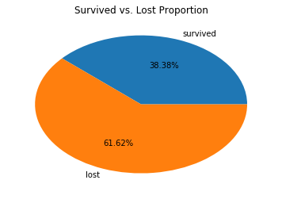

```python
num_survived = len(titanic_df[titanic_df.Survived == 1])
num_lost = len(titanic_df[titanic_df.Survived == 0])

print "Number of survived:\t", num_survived
print "Number of lost:\t\t", num_lost

plt.title('Survived vs. Lost Proportion')
plt.pie([num_survived, num_lost], labels=["survived", "lost"], autopct='%1.2f%%')
plt.show()
```

### 3.2 Explore the Gender -- Gender Proportion

We want to explore the proportion of gender. Gender may be related to the survival rate in the following studies.

```
Number of males:	577
Number of famales:	314
```

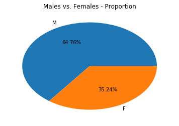

```python
num_male = len(titanic_df[titanic_df.Sex == "male"])
num_female = len(titanic_df[titanic_df.Sex == "female"])

print "Number of males:\t", num_male
print "Number of famales:\t", num_female

plt.title('Males vs. Females - Proportion')
plt.pie([num_male, num_female], labels=["M", "F"], autopct='%1.2f%%')
plt.show()
```

There are about twice males as females. From this result, we find one thing interesting: the proportion of survived and lost is very similar of female and male. We will find is there any correlation between gender and survival rate.

### 3.3 Explore the Gender and Survival

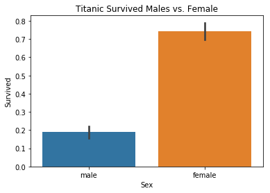

```python
plt.title('Titanic Survived Males vs. Female')
sns.barplot(x=titanic_df.Sex, y=titanic_df.Survived)
plt.show()
```

From this figure, we can know that women has much higher survival rate than men.

### 3.4 Explore the Age -- Age Proportion

```
Number of people age 0 ~ 6:		47
Number of people age 7 ~ 17:		66
Number of people age 19 ~ 40:		630
Number of people age 41 ~ 60:		140
Number of people age 61+:		8
```

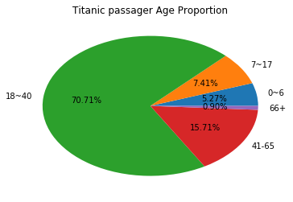

```python
age_0_6 = len(titanic_df[(titanic_df.Age >= 0) & (titanic_df.Age < 7)])
age_7_17 = len(titanic_df[(titanic_df.Age >= 7) & (titanic_df.Age < 18)])
age_18_40 = len(titanic_df[(titanic_df.Age >= 18) & (titanic_df.Age < 41)])
age_41_65 = len(titanic_df[(titanic_df.Age >= 41) & (titanic_df.Age < 66)])
age_66 = len(titanic_df[(titanic_df.Age >= 66)])

print "Number of people age 0 ~ 6:\t\t", age_0_6
print "Number of people age 7 ~ 17:\t\t", age_7_17
print "Number of people age 19 ~ 40:\t\t", age_18_40
print "Number of people age 41 ~ 60:\t\t", age_41_65
print "Number of people age 61+:\t\t", age_66

plt.title('Titanic passager Age Proportion')
plt.pie([age_0_6, age_7_17, age_18_40, age_41_65, age_66], labels=["0~6", "7~17", "18~40", "41-65", "66+"], autopct='%1.2f%%')
plt.show()
```

### 3.5 Explore the Age -- Age Distribution

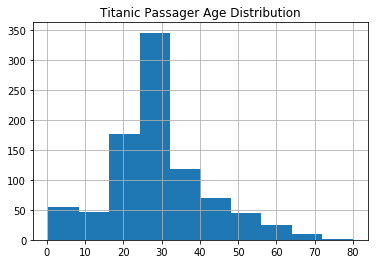

```python
plt.title('Titanic Passager Age Distribution')
titanic_df["Age"].hist()
plt.show()
```

From the age proportion and distribution, we know that most of Titanic onboard people are in range 20 ~ 40

### 3.6 Explore the Age and Survival

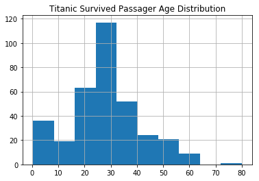

```python
plt.title('Titanic Survived Passager Age Distribution')
titanic_df[titanic_df.Survived==1]["Age"].hist()
plt.show()
```

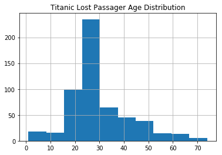

```python
plt.title('Titanic Lost Passager Age Distribution')
titanic_df[titanic_df.Survived==0]["Age"].hist()
plt.show()
```

From the above two histogram plots, we can know that:

```
1. Most of the children survived
2. There are still many adaults survived, we cannot tell difference from this exploration
```

### 3.7 Explore the Embarkation

```
Number of embarked Cherbourg:	168
Number of embarked Queenstown:	77
Number of embarked Southampton:	644
```

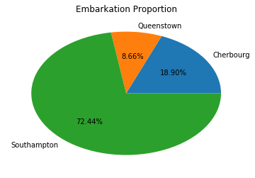

```python
# C = Cherbourg, Q = Queenstown, S = Southampton

num_embarked_C = len(titanic_df[titanic_df.Embarked == "C"])
num_embarked_Q = len(titanic_df[titanic_df.Embarked == "Q"])
num_embarked_S = len(titanic_df[titanic_df.Embarked == "S"])

print "Number of embarked Cherbourg:\t", num_embarked_C
print "Number of embarked Queenstown:\t", num_embarked_Q
print "Number of embarked Southampton:\t", num_embarked_S


plt.title('Embarkation Proportion')
plt.pie([num_embarked_C, num_embarked_Q, num_embarked_S], labels=["Cherbourg", "Queenstown", "Southampton"], autopct='%1.2f%%')
plt.show()
```

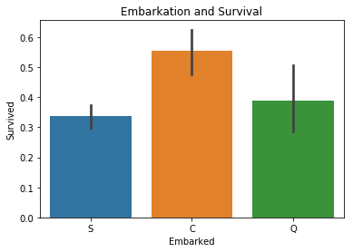

```python
plt.title("Embarkation and Survival")
sns.barplot(x=titanic_df["Embarked"], y=titanic_df["Survived"])
plt.show()
```

### 3.8 Explore the Parch and Sibsp

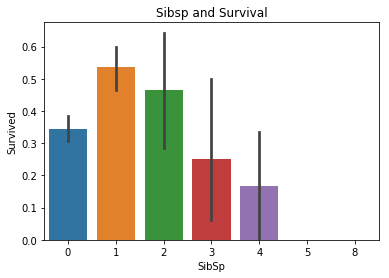

```python
plt.title("Sibsp and Survival")
sns.barplot(x=titanic_df["SibSp"], y=titanic_df["Survived"])
plt.show()
```

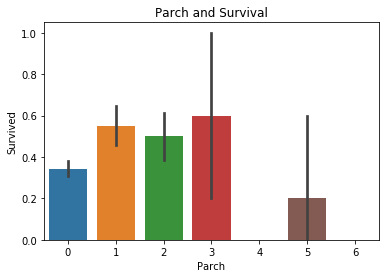

```python
plt.title("Parch and Survival")
sns.barplot(x=titanic_df["Parch"], y=titanic_df["Survived"])
plt.show()
```

### 3.9 Explore the Survival, Gender and Pclass

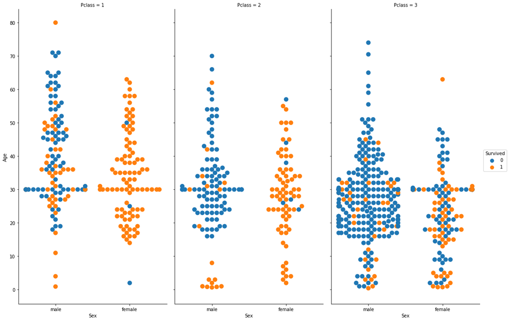

```python
sns.factorplot(data=titanic_df, col='Pclass', x='Sex', y='Age', hue='Survived',
               kind='swarm', size=10, aspect=0.5, s=10)
plt.yticks(np.arange(0,81,10));
plt.show()
```

```python
def age_sex(row):
    """
    Returns 'child' for passengers younger than 18, 'elder' for passengers 65 or older,
    and the passenger's sex otherwise.
    """
    if row['Age'] < 18:
        return 'children'
    elif row['Age'] >= 65:
        return 'old'
    else:
        return row['Sex']

titanic_df['AgeSex'] = titanic_df.apply(age_sex, axis=1)
```

```python
asp_total = titanic_df.groupby(['AgeSex', 'Pclass'])['Survived'].count()
asp_survived = titanic_df.groupby(['AgeSex', 'Pclass'])['Survived'].sum()

groups_df = pd.DataFrame({
                         "group": ["children"] * 3 + ["women"] * 3 + ["men"] * 3 + ["old"] * 3,
                         "class": [1, 2, 3] * 4,
                         "num_aboard": asp_total.values,
                         "num_survived": asp_survived.values,
                         "num_lost": (asp_total - asp_survived).values
                        })

groups_df
```

|  | class | group | num_aboard | num_lost | num_survived |
| --- | --- | --- | --- | --- | --- |
| 0 | 1 | children | 12 | 1 | 11 |
| 1 | 2 | children | 23 | 2 | 21 |
| 2 | 3 | children | 78 | 49 | 29 |
| 3 | 1 | women | 86 | 2 | 84 |
| 4 | 2 | women | 64 | 6 | 58 |
| 5 | 3 | women | 109 | 56 | 53 |
| 6 | 1 | men | 112 | 72 | 40 |
| 7 | 2 | men | 95 | 87 | 8 |
| 8 | 3 | men | 301 | 264 | 37 |
| 9 | 1 | old | 6 | 5 | 1 |
| 10 | 2 | old | 2 | 2 | 0 |
| 11 | 3 | old | 3 | 3 | 0 |

```python
groups_df["percentage_survival(%)"] = np.round(groups_df.num_survived / groups_df.num_aboard * 100, 2)
groups_df["percentage_lost(%)"] = np.round(groups_df.num_lost / groups_df.num_aboard * 100, 2)
groups_df
```

|  | class | group | num_aboard | num_lost | num_survived | percentage_survival(%) | percentage_lost(%) |
| --- | --- | --- | --- | --- | --- | --- | --- |
| 0 | 1 | children | 12 | 1 | 11 | 91.67 | 8.33 |
| 1 | 2 | children | 23 | 2 | 21 | 91.30 | 8.70 |
| 2 | 3 | children | 78 | 49 | 29 | 37.18 | 62.82 |
| 3 | 1 | women | 86 | 2 | 84 | 97.67 | 2.33 |
| 4 | 2 | women | 64 | 6 | 58 | 90.62 | 9.38 |
| 5 | 3 | women | 109 | 56 | 53 | 48.62 | 51.38 |
| 6 | 1 | men | 112 | 72 | 40 | 35.71 | 64.29 |
| 7 | 2 | men | 95 | 87 | 8 | 8.42 | 91.58 |
| 8 | 3 | men | 301 | 264 | 37 | 12.29 | 87.71 |
| 9 | 1 | old | 6 | 5 | 1 | 16.67 | 83.33 |
| 10 | 2 | old | 2 | 2 | 0 | 0.00 | 100.00 |
| 11 | 3 | old | 3 | 3 | 0 | 0.00 | 100.00 |

## 4. Conclusion

### 4.1 Analysis Result

1. Children and women has very high survival percentage, especially in Class 1 and 2.
2. Men in Class 1 have higher survival rate than other classes. While children and women in Class 3 has lower survival rate than other classes.
3. Old people have very low survival rate.

## 5. Future Works

1. The dataset has a lot of missing values for the `Cabin` column. These values can be helpful if we know the boat structure. `Cabin` maps the location in the boat. When the collision happens, many people in these part of boat do not have time to save themselves. It can be an import and interesting part to analysis.
2. `Embarked` data can be interesting if we know much about people's nationality data. Because the Titanic trip starts from Southampton, and pass Cherbourg and Queenstown. Then it leave Queenstown to New York. There are some people exchange in the two stops.
3. The data include people's name, we can do a text match with `Parch` and `SibSp` data to find some relationship of those people.